# LDA

Tuo Liu

2023-02-13

## Linear Discriminant Analysis (LDA)

Discriminant Analysis (DA) predicts the probability of belonging to a given class based on a set of original variables.

- LDA: Uses linear combinations of predictors to predict the class of a given observation. Assumes that the predictor variables (p) are normally distributed and the classes have identical variances (for univariate analysis, p=1) or identical covariance matrices (for multivariate analysis, p > 1).
- QDA: quadratic discriminant analysis is more flexible than LDA…
- the list goes on…

Let’s focus on the application of linear algebra on statistics here.

## Mathematics & Objective function

The goal of LDA is to find a direction (basis vectors) in the data space that maximally separates categories of data. The objective function is defined as:
$$\tag{1}
\begin{equation}
\lambda=\frac{||\mathbb{X_B}\vec{w}||^2}{||\mathbb{X_W}\vec{w}||^2}
\end{equation}$$
In other words: we want to find a set of feature weights $\vec{w}$ that maximize the ratio of the variance of data feature $\mathbb{X_B}$, to the variance of data feature $\mathbb{X_W}$.

Given $||\mathbb{X_B}\vec{w}||^2=\mathbb{w^TX_B^T}\mathbb{X_B}\mathbb{w}, \mathbb{X_B^T}\mathbb{X_B}=\mathbb{C_B}$, to express equation (1) algebraically and generally
$$\begin{equation}
\tag{2}
\Lambda=\frac{\mathbb{W^TX_B^T}\mathbb{X_B}\mathbb{W}}{\mathbb{W^TX_W^T}\mathbb{X_W}\mathbb{W}}
\Rightarrow
\Lambda=\mathbb{W^{-1}C_W^{-1}C_BW}
\Rightarrow
\mathbb{C_BW}=\Lambda\mathbb{C_WW}
\end{equation}$$
To express equation (2) algebraically, the solution to LDA comes from a generalized eigendecomposition, i.e., simultaneous diagonalization of two matrices, on two covariance matrices. The eigenvectors are the weights, and the generalized eigenvalues are the variance ratio of each component.

## Cons

Although LDA is widely used as a data reduction technique, it suffers from a number of problems.

- LDA fails to find the lower dimensional space if the dimensions are much higher than the number of samples in the data matrix
  - Solution: LDA-SSS, PCA-LDA, RLDA
- If different classes are not separable linearly, LDA cannot discriminate between these classes (Tharwat et al. 2017)

## Tutorial

To project the original data matrix onto a lower dimensional space, three steps needed to be performed:

- calculate the separability between different classes (i.e. the distance between the means of different classes `between-class variance`)
- calculate the distance between the mean and the samples of each class (`within-class variance`)
- construct the lower dimensional space which maximizes the between-class variance and minimizes the within-class variance

### Between & Within class variance

- Class means
  $$\mu_j=\frac{1}{n_j}\sum_{x_i \in w_j}{x_i}$$

```r
# exmaple data classes
w1 <- matrix(c(1.00, 2.00, 3.00, 4.00, 5.00, 2.00, 3.00, 3.00, 5.00, 5.00), ncol = 2)
w2 <- matrix(c(4.00, 5.00, 5.00, 3.00, 5.00, 6.00, 2.00, 0.00, 2.00, 2.00, 3.00, 3.00), ncol = 2)
w1
```

```
##      [,1] [,2]
## [1,]    1    2
## [2,]    2    3
## [3,]    3    3
## [4,]    4    5
## [5,]    5    5
```

```r
w2
```

```
##      [,1] [,2]
## [1,]    4    2
## [2,]    5    0
## [3,]    5    2
## [4,]    3    2
## [5,]    5    3
## [6,]    6    3
```

- Total mean
  $$\mu=\frac{1}{N}\sum_{i=1}^{N}{x_i}=\sum_{i=1}^{c}\frac{n_i}{N}\mu_i$$

```r
# calculate class means and total mean
u1 <- colMeans(w1) %>% t()
u2 <- colMeans(w2) %>% t()
u <- u1*nrow(w1)/(nrow(w1)+nrow(w2))+u2*nrow(w2)/(nrow(w1)+nrow(w2))
u1
```

```
##      [,1] [,2]
## [1,]    3  3.6
```

```r
u2
```

```
##          [,1] [,2]
## [1,] 4.666667    2
```

```r
u
```

```
##          [,1]     [,2]
## [1,] 3.909091 2.727273
```

- Between-class variance of each class $S_{B_i}$ & total between-class variance $S_B$

```r
sb1 <- 5*t(u1-u) %*% (u1-u)
sb1
```

```
##           [,1]      [,2]
## [1,]  4.132231 -3.966942
## [2,] -3.966942  3.808264
```

$$S_{B_1}=n_1(\mu_1-\mu)^T(\mu_1-\mu)=5\begin{pmatrix}-0.91 &
0.87\end{pmatrix}^T\begin{pmatrix}-0.91 &
0.87\end{pmatrix}=\begin{pmatrix}4.13 & -3.97\\ -3.97 &
3.81\end{pmatrix}$$

```r
sb2 <- 6*t(u2-u) %*% (u2-u)
sb2
```

```
##           [,1]      [,2]
## [1,]  3.443526 -3.305785
## [2,] -3.305785  3.173554
```

```r
sb <- sb1 + sb2
sb # between-class covariance matrix
```

```
##           [,1]      [,2]
## [1,]  7.575758 -7.272727
## [2,] -7.272727  6.981818
```

- Within-class variance

```r
# mean-center
d1 <- sweep(w1, 2, u1)
d2 <- sweep(w2, 2, u2)
d1
```

```
##      [,1] [,2]
## [1,]   -2 -1.6
## [2,]   -1 -0.6
## [3,]    0 -0.6
## [4,]    1  1.4
## [5,]    2  1.4
```

```r
d2
```

```
##            [,1] [,2]
## [1,] -0.6666667    0
## [2,]  0.3333333   -2
## [3,]  0.3333333    0
## [4,] -1.6666667    0
## [5,]  0.3333333    1
## [6,]  1.3333333    1
```

#### Class-Independent Method

within-class variance for each class ($S_{Wi}$) is calculated as follows
$$\mathbb{S_{W_j}}=\mathbb{d_j}^T\mathbb{d_j}=\sum_{i=1}^{n_j}\mathbb{(x_{ij-\mu_j})}^T\mathbb{(x_{ij-\mu_j})}$$
The total within-class matrix ($S_W$) is then calculated as follows
$$\mathbb{S_W}=\sum_{i=1}^{c}\mathbb{S_{w_i}}$$

```r
sw1 <- t(d1) %*% d1
sw2 <- t(d2) %*% d2
sw <- sw1 + sw2
sw1
```

```
##      [,1] [,2]
## [1,]   10  8.0
## [2,]    8  7.2
```

```r
sw2
```

```
##          [,1] [,2]
## [1,] 5.333333    1
## [2,] 1.000000    6
```

```r
sw # within-class covariance matrix
```

```
##          [,1] [,2]
## [1,] 15.33333  9.0
## [2,]  9.00000 13.2
```

### Generalized Eigendecomposition

Do generalized eigendecomposition with the between-, and within-class covariance matrix

```r
s <- eigen(solve(sw) %*% sb)
s$values
```

```
## [1] 2.783885 0.000000
```

```r
s$vectors
```

```
##            [,1]       [,2]
## [1,]  0.6773521 -0.6925318
## [2,] -0.7356590 -0.7213873
```

### Projection on new space

```r
# class 1 projection coordinate on v1
y11 <- w1 %*% s$vectors[,1]
y11
```

```
##            [,1]
## [1,] -0.7939658
## [2,] -0.8522727
## [3,] -0.1749206
## [4,] -0.9688864
## [5,] -0.2915343
```

```r
# class 2 projection coordinate on v1
y21 <- w2 %*% s$vectors[,1]
y21
```

```
##           [,1]
## [1,] 1.2380905
## [2,] 3.3867605
## [3,] 1.9154426
## [4,] 0.5607384
## [5,] 1.1797836
## [6,] 1.8571357
```

```r
# class 1 projection coordinate on v2
y12 <- w1 %*% s$vectors[,2]
y12
```

```
##           [,1]
## [1,] -2.135306
## [2,] -3.549226
## [3,] -4.241757
## [4,] -6.377064
## [5,] -7.069596
```

```r
# class 2 projection coordinate on v2
y22 <- w2 %*% s$vectors[,2]
y22
```

```
##           [,1]
## [1,] -4.212902
## [2,] -3.462659
## [3,] -4.905434
## [4,] -3.520370
## [5,] -5.626821
## [6,] -6.319353
```

#### plot

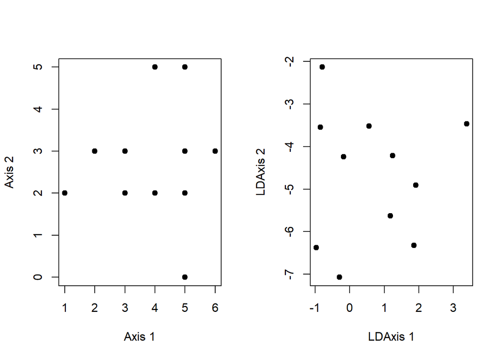

```r
class <- c(rep("1", 5), rep("2",6))
df <- rbind(w1,w2) |> as.data.frame() |> cbind(class) |> rename(ft1=V1, ft2=V2)

y1 <- rbind(y11, y21)
y2 <- rbind(y12, y22)
df_p <- cbind(y1,y2) |> as.data.frame() |> cbind(class) |> rename(ft1=V1, ft2=V2)


# plot
par(mfrow=c(1,2))
plot(df$ft1,df$ft2, type="p", pch=19, xlab = "Axis 1", ylab = "Axis 2")
plot(df_p$ft1,df_p$ft2, type="p", pch=19, xlab = "LDAxis 1", ylab = "LDAxis 2")
```

## Implementation in R

```r
# Load the data
data("iris")

# Split the data into training (80%) and test set (20%)
set.seed(123)
training.samples <- iris$Species %>%
  createDataPartition(p = 0.8, list = FALSE)
train.data <- iris[training.samples, ]
test.data <- iris[-training.samples, ]

# Estimate preprocessing parameters
preproc.param <- train.data %>%
  preProcess(method = c("center", "scale"))

# Transform the data using the estimated parameters
train.transformed <- preproc.param %>% predict(train.data)
test.transformed <- preproc.param %>% predict(test.data)

# fit LDA
model <- lda(Species~., data = train.transformed)
model
```

```
## Call:
## lda(Species ~ ., data = train.transformed)
##
## Prior probabilities of groups:
##     setosa versicolor  virginica
##  0.3333333  0.3333333  0.3333333
##
## Group means:
##            Sepal.Length Sepal.Width Petal.Length Petal.Width
## setosa       -1.0112835  0.78048647   -1.2900001  -1.2453195
## versicolor    0.1014181 -0.68674658    0.2566029   0.1472614
## virginica     0.9098654 -0.09373989    1.0333972   1.0980581
##
## Coefficients of linear discriminants:
##                     LD1         LD2
## Sepal.Length  0.6794973  0.04463786
## Sepal.Width   0.6565085 -1.00330120
## Petal.Length -3.8365047  1.44176147
## Petal.Width  -2.2722313 -1.96516251
##
## Proportion of trace:
##    LD1    LD2
## 0.9902 0.0098
```

The lda() outputs contain the following elements:

- Prior probabilities of groups: the proportion of training observations in each group. For example, there are 33% of the training observations in the setosa group
- Group means: group center of gravity. Shows the mean of each variable in each group.
- Coefficients of linear discriminants: Shows weights of the linear combination of predictor variables that are used to form the LDA spaces.

inspect model results

The predict() function returns the following elements:

- class: predicted classes of observations.
- posterior: is a matrix whose columns are the groups, rows are the individuals and values are the posterior probability that the corresponding observation belongs to the groups.
- x: contains the linear discriminants (latent spaces coordinates)

```r
# Make predictions
predictions <- model %>% predict(test.transformed)
names(predictions)
```

```
## [1] "class"     "posterior" "x"
```

```r
# Model accuracy
mean(predictions$class==test.transformed$Species)
```

```
## [1] 0.9666667
```

```r
# Predicted classes
head(predictions$class, 6)
```

```
## [1] setosa setosa setosa setosa setosa setosa
## Levels: setosa versicolor virginica
```

```r
# Predicted probabilities of class memebership.
head(predictions$posterior, 6)
```

```
##    setosa   versicolor    virginica
## 1       1 3.978425e-22 1.319337e-43
## 2       1 1.038098e-17 3.967605e-38
## 6       1 2.882148e-21 2.041612e-41
## 16      1 8.381782e-28 7.486309e-50
## 23      1 6.531615e-25 3.414098e-47
## 34      1 1.089899e-28 7.865614e-52
```

```r
# Linear discriminants
head(predictions$x, 3)
```

```
##        LD1        LD2
## 1 8.162939 -0.5052768
## 2 7.202713  0.7111062
## 6 7.816243 -1.7327151
```

plot

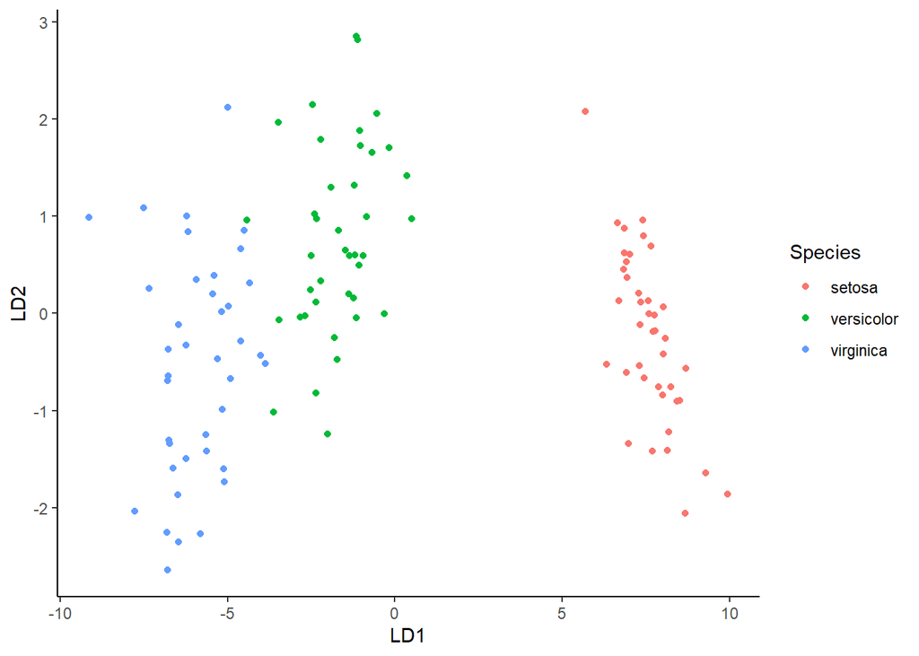

```r
lda.data <- cbind(train.transformed, predict(model)$x)

# plot
ggplot(lda.data, aes(LD1, LD2)) +
  geom_point(aes(color = Species))
```

## Reference

Tharwat, Alaa, Tarek Gaber, Abdelhameed Ibrahim, and Aboul Ella Hassanien. 2017. “Linear Discriminant Analysis: A Detailed Tutorial.” *Ai Communications* 30 (May): 169–90,. https://doi.org/10.3233/AIC-170729.